# 02-immune-deconv-medulloblastoma

Chao Di, dichao83@gmail.com

## Background

**Problem 2**  
Update the [immune-deconv module](https://github.com/rokitalab/OpenPedCan-Project-CNH/tree/dev/analyses/immune-deconv) to add an analysis which investigates whether there are differences in the immune cell composition in tumors with different medulloblastoma subtypes (WNT, SHH, Group3, and Group4). Generate at least one plot to show your findings. - The histologies.tsv file includes information about the samples, biospecimen ids, cohorts, cancer group, molecular subtype, etc. A readme can be found in tab 1 of the excel file [here](https://github.com/rokitalab/OpenPedCan-Project-CNH/blob/dev/tables/results/SuppTable1-Histologies.xlsx).

```r
library(tidyverse)
library(ggplot2)
library(pheatmap)
library(RColorBrewer)
```

## Load results from `01-immune-deconv.R`

**Analyze results from two methods `quanTIseq` and `xCell`**

### quanTIseq

“quanTIseq looks at fewer cell types, the scores can be interpreted as absolute fractions, thereby allowing comparison both across samples and cell types, [as described](https://omnideconv.org/immunedeconv/articles/immunedeconv.html#interpretation-of-scores).

#### Show cell type fractions for each sample

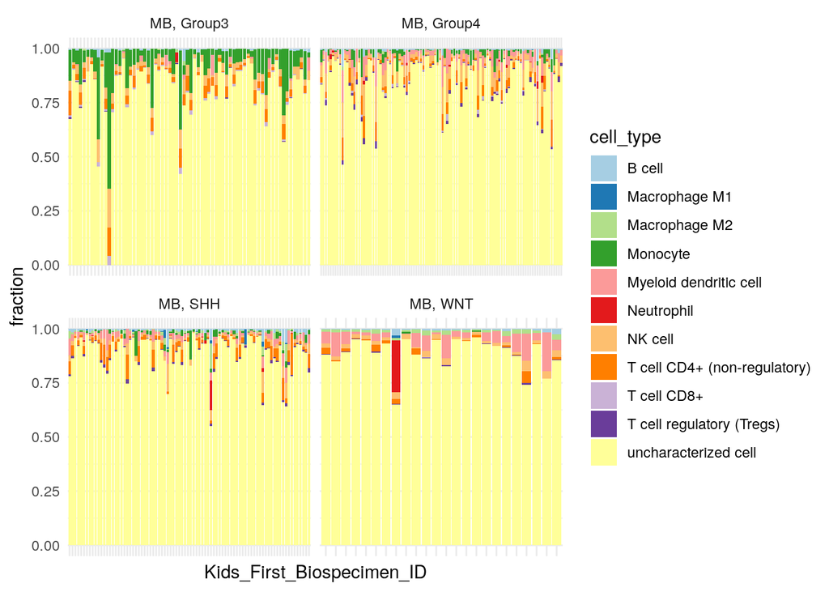

```r
quantiseq_deconv <- readRDS("results/quantiseq_output.rds")
quantiseq_MB <- quantiseq_deconv %>%
  filter(cancer_group == "Medulloblastoma")

quantiseq_MB %>%
  ggplot(aes(x = Kids_First_Biospecimen_ID, y = fraction, fill = cell_type)) +
  geom_bar(stat = "identity") +
  facet_wrap(~ molecular_subtype, scales = "free_x") +
  # scale_fill_manual(values = palette) +
  scale_fill_brewer(palette = "Paired") +
  theme_minimal() +
  theme(axis.text.x = element_blank())
```

#### Average cell type fractions per molecular subtype

As there are so many samples for each molecular_subtype, use average cell type composition per subtype

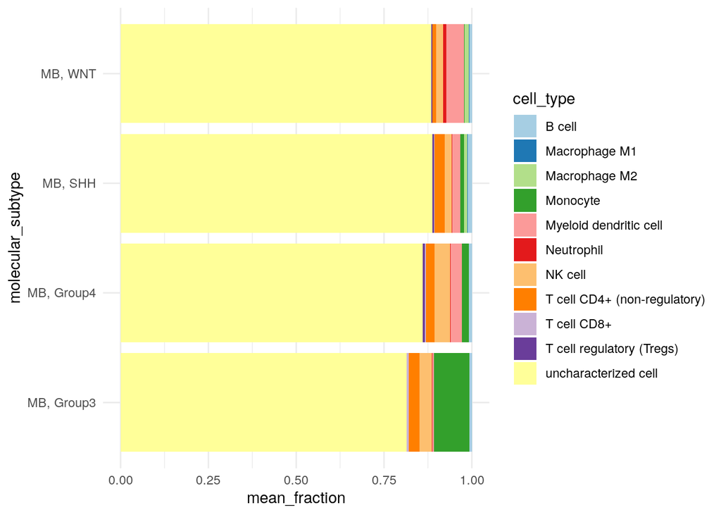

```r
quantiseq_MB %>%
  group_by(molecular_subtype, cell_type) %>%
  summarise(mean_fraction = mean(fraction, na.rm = TRUE)) %>%
  ggplot(aes(x = molecular_subtype, y = mean_fraction, fill = cell_type)) +
  geom_bar(stat = "identity") +
  coord_flip() +
  # scale_fill_manual(values = palette) +
  scale_fill_brewer(palette = "Paired") +
  theme_minimal()
```